# Weight Lifting Analysis

Brandon Shelton

July 6, 2016

## Overview

This document walks through the analysis performed and R code executed to accurately predict the correct *classe* type of bicep curl performed by a weight lifter. For additional information on the data used, please visit the “Weight Lifting Exercises Dataset” section at http://groupware.les.inf.puc-rio.br/har.

The two datasets made available for this analysis are:

- Training Data: https://d396qusza40orc.cloudfront.net/predmachlearn/pml-training.csv
- Test Data: https://d396qusza40orc.cloudfront.net/predmachlearn/pml-testing.csv

The abovementioned “Test Data” is missing its output variable (*classe*) because it is intended be used as the model’s validation dataset. Thus, the “Training Data” is subset into training and test datasets in order to gauge the model’s accuracy.

```r
#load required packages, set seed
library(caret)
library(data.table)
set.seed(12345)

#read the pml-training.csv file
setwd("C:/Users/bshelto1/Documents")
training_a <- read.csv("./pml-training.csv", header = TRUE)

#create the training and test datasets
inTrain <- createDataPartition(y = training_a$classe, p = 0.7, list = FALSE)
training <- training_a[inTrain, ]
testing <- training_a[-inTrain, ]
```

## Pre-Processing

#### Removing Irrelevant Predictors

Several of the 159 predictor variables seem to be easily plotted against the categorical *classe* variable for quick correlation recognition. When illustrated in a Scatter Plot Matrix, it is evident that variable *X* is highly correlated wih *classe* and is presumably a row ID. This exploratory analysis has led to the removal of using *X* as a predictor variable.

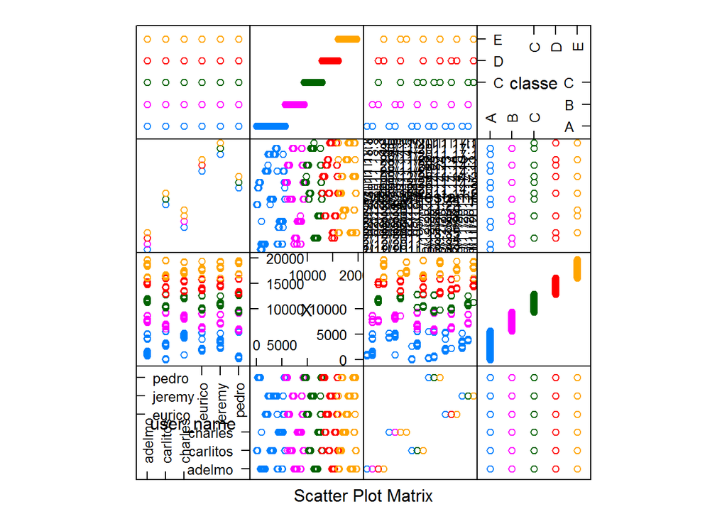

```r
featurePlot(x = training[, c("user_name", "X", "cvtd_timestamp", "classe")],
            y = training$classe,
            plot = "pairs")
```

```r
training$X <- NULL
testing$X <- NULL
```

#### Imputing Missing Values

Many of the training dataset’s predictor variables contain NA values, which do not work well with categorical machine learning algorithms. The caret package’s “knnImpute” method is used to replace these NA values with the mean values of the most similar looking datapoints, based on other predictor variables. The “knnImpute” method also centers and scales each numeric variable as close as it can to a column mean of 0 and column standard deviation of 1.

```r
pre_obj <- preProcess(training[, -159], method = "knnImpute")
training2 <- predict(pre_obj, training[, -159])
testing2 <- predict(pre_obj, testing[, -159])
```

#### Identification of Near Zero Variance Predictors

The nearZeroVar() function identifies predictors with little-to-no predictive value due to their extereme consistency throughout the entire dataset. Near zero variance predictors are then taken out of the dataset to reduce model processing requirements without negating model accuracy.

```r
nzvar <- subset(nearZeroVar(training2, saveMetrics = TRUE), nzv == TRUE)
print(nzvar)
```

```
##                           freqRatio percentUnique zeroVar  nzv
## new_window                 49.31868    0.01455922   FALSE TRUE
## kurtosis_roll_belt       1923.42857    1.94365582   FALSE TRUE
## kurtosis_picth_belt       561.00000    1.63063260   FALSE TRUE
## kurtosis_yaw_belt          49.31868    0.01455922   FALSE TRUE
## skewness_roll_belt       1923.42857    1.92909660   FALSE TRUE
## skewness_roll_belt.1      561.00000    1.69614909   FALSE TRUE
## skewness_yaw_belt          49.31868    0.01455922   FALSE TRUE
## max_yaw_belt              641.14286    0.45133581   FALSE TRUE
## min_yaw_belt              641.14286    0.45133581   FALSE TRUE
## amplitude_yaw_belt         52.18605    0.02911844   FALSE TRUE
## kurtosis_roll_arm         258.92308    1.62335299   FALSE TRUE
## kurtosis_picth_arm        249.33333    1.60879377   FALSE TRUE
## kurtosis_yaw_arm         1683.00000    1.93637621   FALSE TRUE
## skewness_roll_arm         258.92308    1.62335299   FALSE TRUE
## skewness_pitch_arm        249.33333    1.60879377   FALSE TRUE
## skewness_yaw_arm         1683.00000    1.94365582   FALSE TRUE
## kurtosis_roll_dumbbell   6732.00000    1.97277426   FALSE TRUE
## kurtosis_picth_dumbbell 13464.00000    1.99461309   FALSE TRUE
## kurtosis_yaw_dumbbell      49.31868    0.01455922   FALSE TRUE
## skewness_roll_dumbbell   6732.00000    1.98005387   FALSE TRUE
## skewness_pitch_dumbbell  6732.00000    1.98005387   FALSE TRUE
## skewness_yaw_dumbbell      49.31868    0.01455922   FALSE TRUE
## max_yaw_dumbbell         1035.69231    0.46589503   FALSE TRUE
## min_yaw_dumbbell         1035.69231    0.46589503   FALSE TRUE
## amplitude_yaw_dumbbell     49.68266    0.02183883   FALSE TRUE
## kurtosis_roll_forearm     232.13793    1.57239572   FALSE TRUE
## kurtosis_picth_forearm    228.20339    1.57239572   FALSE TRUE
## kurtosis_yaw_forearm       49.31868    0.01455922   FALSE TRUE
## skewness_roll_forearm     232.13793    1.57239572   FALSE TRUE
## skewness_pitch_forearm    228.20339    1.55055689   FALSE TRUE
## skewness_yaw_forearm       49.31868    0.01455922   FALSE TRUE
## max_yaw_forearm           232.13793    0.29118439   FALSE TRUE
## min_yaw_forearm           232.13793    0.29118439   FALSE TRUE
## amplitude_yaw_forearm      62.62326    0.02183883   FALSE TRUE
```

```r
`%ni%` <- Negate(`%in%`)
training3 <- training2[, names(training2) %ni% rownames(nzvar)]
testing3 <- testing2[, names(testing2) %ni% rownames(nzvar)]
```

#### Principle Component Analysis

The remaining 121 *numeric* predictors are tested for correlation and combined into weighted predictors through Principle Component Analysis (PCA). Caret’s preProcess() function contains a “pca” method for this transformation. Consolidating correlated predictors into a smaller group of combined predictors reduces noise that the larger group of predictors may present, and much like the Near Zero Variance predictor removal, PCA reduces required processing power for model training.

Prior to running the preProcess() function, an analysis of the numeric training predictors confirms that there are a large number of predictor pairings with at least an 80% correlation remaining in the dataset.

```r
fac_vars <- c("user_name", "cvtd_timestamp")
training4a <- training3[, names(training3) %ni% fac_vars]
m <- abs(cor(training4a))
diag(m) <- 0
data.table(which(m > 0.8, arr.ind = T))
```

```
##      row col
##   1:   6   4
##   2:   7   4
##   3:   8   4
##   4:   9   4
##   5:  10   4
##  ---
## 226: 112 113
## 227: 116 115
## 228:  85 116
## 229:  87 116
## 230: 115 116
```

The Principle Component Analysis further reduces the datasets size and noise by combining variables into 37 predictors (35 PCs and 2 factor variables).

```r
pre_pca <- preProcess(training4a, method = "pca")
training4b <- predict(pre_pca, training4a)
classe <- training$classe
training4 <- cbind(training4b, training3[, names(training3) %in% fac_vars], classe)

testing4a <- testing3[, names(testing3) %ni% fac_vars]
testing4b <- predict(pre_pca, testing4a)
testing4b <- predict(pre_pca, testing4a)
testing4 <- cbind(testing4b, testing3[, names(testing3) %in% fac_vars])

dim(training4)
```

```
## [1] 13737    38
```

## Predicting with the Random Forest Model

#### Cross Validation Setting

This analysis is performed using a k-folds cross validation, where k = 10. 10 k-folds was chosen because the data set is large enough for 10 training iterations to deliver a non-biased avereage estimated out-of-sample error while minimizing the model’s required processing power. Additional power is provided through the prescription of parallel processing, allowing the model training to use all but 1 machine core, which will remain reserved for other processing needs.

```r
library(parallel)
library(doParallel)
cluster <- makeCluster(detectCores() - 1)
registerDoParallel(cluster)

fitControl <- trainControl(method = "cv",
                           number = 10,
                           allowParallel = TRUE)
```

#### Random Forest

The Random Forest model was chosen because it is a powerful ensemble algorithm that works well with categorical outputs.

```r
modFit_rf <- train(classe ~ ., method = "rf", data = training4, trControl = fitControl)
stopCluster(cluster)
```

Using this training model to predict *classe* on the testing dataset results in a Accuracy rate of > 96%. The model’s sensitivity, specificity, positive predictive value, and negative predictive values are > 90% for every category. Based on the the performance with the testing dataset, I would expect this model’s out of sample error to be ~5%, which would result in it being able to predict 19 out of the 20 validation dataset outcomes correctly.

```r
te_predict_rf <- predict(modFit_rf, testing4)
confusionMatrix(testing$classe, te_predict_rf)
```

```
## Confusion Matrix and Statistics
##
##           Reference
## Prediction    A    B    C    D    E
##          A 1635   29   10    0    0
##          B   30 1090   19    0    0
##          C    4   30  977   12    3
##          D    0    0   41  908   15
##          E    1    0    2   14 1065
##
## Overall Statistics
##
##                Accuracy : 0.9643
##                  95% CI : (0.9593, 0.9689)
##     No Information Rate : 0.2838
##     P-Value [Acc > NIR] : < 2.2e-16
##
##                   Kappa : 0.9549
##  Mcnemar's Test P-Value : NA
##
## Statistics by Class:
##
##                      Class: A Class: B Class: C Class: D Class: E
## Sensitivity            0.9790   0.9487   0.9314   0.9722   0.9834
## Specificity            0.9907   0.9897   0.9899   0.9887   0.9965
## Pos Pred Value         0.9767   0.9570   0.9522   0.9419   0.9843
## Neg Pred Value         0.9917   0.9876   0.9852   0.9947   0.9963
## Prevalence             0.2838   0.1952   0.1782   0.1587   0.1840
## Detection Rate         0.2778   0.1852   0.1660   0.1543   0.1810
## Detection Prevalence   0.2845   0.1935   0.1743   0.1638   0.1839
## Balanced Accuracy      0.9849   0.9692   0.9606   0.9804   0.9899
```